# Cx4073 : Assignment 2

GUVVALA SANJUSHA

U1521432J

## Marketing Campaign of a Bank

A certain Bank is conducting a marketing campaign to offer a specific *Term Deposit* to a large demography of targeted clients. The data provided in this exercise is related with direct marketing campaigns (phone calls) of the Bank. The classification goal is to predict if the targeted person will subscribe to the Term Deposit offered by the Bank. The Bank also wants to identify the top three variables that may affect the subscription chances of the targeted person, and they also want to know how to increase the chances for the person to subscribe to the Term Deposit.

## Assignment 2: Perform Exploratory Analysis, Model Building, Prediction and Interpretation

Steps : Parts of code for Assignment 2 Dataset used : assign2_MarketingData.csv

Libraries used:

```r
#install.packages("VIM")
#install.packages("mice")
#install.packages("caret")
#install.packages("tree")
#install.packages("randomForest")
library(VIM)
library(mice)
library(caret)
library(tree)
library(randomForest)
```

Detailed exploratory analysis of Marketing data

Step 1 : Import the dataset assign2_MarketingData.csv

```r
market_data <- read.csv("assign2_MarketingData.csv", header = TRUE)
market_data[market_data=="unknown"] <- NA
```

Step 2 : Perform some basic Explorations

2a : dimension of the dataset

```r
dim(market_data)
```

```
## [1] 30000    21
```

2b : labels of the columns/variables

```r
names(market_data)
```

```
##  [1] "Age"           "Job"           "Marital"       "Education"
##  [5] "Default"       "Housing"       "Loan"          "Contact"
##  [9] "Month"         "Day"           "Duration"      "Campaign"
## [13] "PrevDays"      "Previous"      "PrevOutcome"   "EmpVarRate"
## [17] "ConPriceIndex" "ConConfIndex"  "EuriborRate"   "NumEmp"
## [21] "Subscribed"
```

Description of variables is as follows The following table summarizes the variables in the dataset. Check the data description carefully.

| Variable | Description | Type | Numeric / Categorical |
| --- | --- | --- | --- |
| Age | Age of the person | Personal Profile | Numeric |
| Job | Job Profile of the person | Personal Profile | Categorical |
| Marital | Marital Status of the person | Personal Profile | Categorical |
| Education | Highest Educational Qualification of the person | Personal Profile | Categorical |
| Default | Does the person have Credit in Default? | Financial Profile | Categorical |
| Housing | Does the person have a Housing Loan? | Financial Profile | Categorical |
| Loan | Does the person have a Personal Loan? | Financial Profile | Categorical |
| Contact | Type of Contact Number for Communication | Personal Profile | Categorical |
| Month | Month of Year for the last contact with the person | Campaign Data | Categorical |
| Day | Day of Week for the last contact with the person | Campaign Data | Categorical |
| Duration | The duration of contact during the Last Contact | Campaign Data | Numeric |
| Campaign | Number of contacts with the person during this Campaign | Campaign Data | Numeric |
| PrevDays | Number of days from the last contact during the Previous Campaign | Campaign Data | Numeric |
| Previous | Number of contacts with the person before this Campaign | Campaign Data | Numeric |
| PrevOutcome | Outcome of previous Marketing Campaign for the person | Campaign Data | Categorical |
| EmpVarRate | Employment Variation Rate in the person’s locality | Demographic Info | Numeric |
| ConPriceIndex | Consumer Price Index (monthly) in the person’s locality | Demographic Info | Numeric |
| ConConfIndex | Consumer Confidence Index (monthly) in the person’s locality | Demographic Info | Numeric |
| EuriborRate | Euro Interbank Offered Rate (Euribor) for 3 months | Demographic Info | Numeric |
| NumEmp | Number of Employees (quarterly) in the person’s locality | Demographic Info | Numeric |
| Subscribed | Whether the person has Subscribed to a Term Deposit | Response/Target | Binary(“yes”/“no”) |

Value `unknown` in any categorical variable means the data is not available. `Duration = 0` means no communication during the last contact, or may be that there was *no* previous contact at all. `PrevDays = 999` means there was no previous contact with the person. The goal is to predict the response variable `Subscribed` for each person – that is, whether a person would subscribe to the *Term Deposit* being sold by the Bank.

2c : structure of the dataset

```r
str(market_data)
```

```
## 'data.frame':    30000 obs. of  21 variables:
##  $ Age          : int  33 28 48 24 45 33 31 31 39 37 ...
##  $ Job          : Factor w/ 12 levels "admin","blue-collar",..: 7 8 5 9 1 1 8 8 1 1 ...
##  $ Marital      : Factor w/ 4 levels "divorced","married",..: 3 2 2 3 3 1 1 2 2 2 ...
##  $ Education    : Factor w/ 8 levels "basic4y","basic6y",..: 7 4 7 4 7 7 4 NA 6 4 ...
##  $ Default      : Factor w/ 3 levels "no","unknown",..: 1 1 1 1 1 1 1 1 1 1 ...
##  $ Housing      : Factor w/ 3 levels "no","unknown",..: NA 3 3 1 NA 1 3 3 1 3 ...
##  $ Loan         : Factor w/ 3 levels "no","unknown",..: NA 1 3 1 NA 1 3 1 1 1 ...
##  $ Contact      : Factor w/ 2 levels "cellular","telephone": 2 1 2 1 1 2 1 1 1 2 ...
##  $ Month        : Factor w/ 10 levels "apr","aug","dec",..: 5 7 4 5 8 7 2 5 2 4 ...
##  $ Day          : Factor w/ 5 levels "fri","mon","thu",..: 1 1 3 4 4 1 4 4 1 3 ...
##  $ Duration     : int  38 237 154 253 133 279 242 98 306 29 ...
##  $ Campaign     : int  5 4 1 1 3 1 3 3 3 14 ...
##  $ PrevDays     : int  999 999 999 999 999 999 999 999 999 999 ...
##  $ Previous     : int  0 0 0 0 1 0 0 0 0 0 ...
##  $ PrevOutcome  : Factor w/ 3 levels "failure","nonexistent",..: 2 2 2 2 1 2 2 2 2 2 ...
##  $ EmpVarRate   : num  1.4 -1.8 1.4 -2.9 -3.4 1.1 1.4 -2.9 1.4 1.4 ...
##  $ ConPriceIndex: num  94.5 92.9 93.9 93 92.6 ...
##  $ ConConfIndex : num  -41.8 -46.2 -42.7 -40.8 -30.1 -36.4 -36.1 -40.8 -36.1 -42.7 ...
##  $ EuriborRate  : num  4.959 1.313 4.962 1.262 0.715 ...
##  $ NumEmp       : num  5228 5099 5228 5076 5018 ...
##  $ Subscribed   : Factor w/ 2 levels "no","yes": 1 1 1 1 1 1 1 1 1 1 ...
```

2d : first few rows of the data

```r
head(market_data)
```

```
##   Age           Job  Marital  Education Default Housing Loan   Contact
## 1  33 self-employed   single university      no    <NA> <NA> telephone
## 2  28      services  married highschool      no     yes   no  cellular
## 3  48    management  married university      no     yes  yes telephone
## 4  24       student   single highschool      no      no   no  cellular
## 5  45         admin   single university      no    <NA> <NA>  cellular
## 6  33         admin divorced university      no      no   no telephone
##   Month Day Duration Campaign PrevDays Previous PrevOutcome EmpVarRate
## 1   jun fri       38        5      999        0 nonexistent        1.4
## 2   may fri      237        4      999        0 nonexistent       -1.8
## 3   jul thu      154        1      999        0 nonexistent        1.4
## 4   jun tue      253        1      999        0 nonexistent       -2.9
## 5   nov tue      133        3      999        1     failure       -3.4
## 6   may fri      279        1      999        0 nonexistent        1.1
##   ConPriceIndex ConConfIndex EuriborRate NumEmp Subscribed
## 1        94.465        -41.8       4.959 5228.1         no
## 2        92.893        -46.2       1.313 5099.1         no
## 3        93.918        -42.7       4.962 5228.1         no
## 4        92.963        -40.8       1.262 5076.2         no
## 5        92.649        -30.1       0.715 5017.5         no
## 6        93.994        -36.4       4.855 5191.0         no
```

2e : look at a random sample rows of the data to get the idea of the random distribution of data

```r
sample_index = sample(1:nrow(market_data),20,replace=FALSE)
market_data[sample_index,]
```

```
##       Age           Job  Marital    Education Default Housing Loan
## 22899  26   blue-collar   single   highschool      no      no  yes
## 14854  37         admin  married   university      no     yes  yes
## 19800  34         admin   single professional      no      no   no
## 27741  40         admin divorced professional      no      no   no
## 12881  36    technician  married   university      no     yes   no
## 10076  35    technician   single   highschool    <NA>     yes  yes
## 24829  59       retired divorced professional      no      no   no
## 20806  55    technician  married   highschool      no     yes   no
## 18817  53   blue-collar  married      basic9y      no      no   no
## 16714  28   blue-collar  married      basic6y      no     yes   no
## 6552   40      services  married      basic9y      no      no   no
## 25273  39 self-employed  married professional      no     yes   no
## 28765  56          <NA>  married      basic4y      no     yes   no
## 7975   38   blue-collar   single      basic9y    <NA>     yes   no
```

[output cut: 48 more lines]

2f : summary statistics for all variables

```r
summary(market_data)
```

```
##       Age                 Job           Marital             Education
##  Min.   :17.00   admin      :7636   divorced: 3349   university  :8841
##  1st Qu.:32.00   blue-collar:6723   married :18166   highschool  :6897
##  Median :38.00   technician :4899   single  : 8431   basic9y     :4438
##  Mean   :40.03   services   :2893   unknown :    0   professional:3819
##  3rd Qu.:47.00   management :2089   NA's    :   54   basic4y     :3069
##  Max.   :98.00   (Other)    :5511                    (Other)     :1667
##                  NA's       : 249                    NA's        :1269
##     Default         Housing           Loan            Contact
##  no     :23739   no     :13567   no     :24706   cellular :19094
##  unknown:    0   unknown:    0   unknown:    0   telephone:10906
##  yes    :    2   yes    :15716   yes    : 4577
##  NA's   : 6259   NA's   :  717   NA's   :  717
##
##
##
##      Month       Day          Duration         Campaign
##  may    :9988   fri:5739   Min.   :   0.0   Min.   : 1.000
##  jul    :5299   mon:6190   1st Qu.: 103.0   1st Qu.: 1.000
##  aug    :4479   thu:6255   Median : 179.0   Median : 2.000
##  jun    :3793   tue:5918   Mean   : 258.1   Mean   : 2.544
##  nov    :3037   wed:5898   3rd Qu.: 320.0   3rd Qu.: 3.000
##  apr    :1911              Max.   :4918.0   Max.   :56.000
##  (Other):1493
##     PrevDays        Previous           PrevOutcome      EmpVarRate
##  Min.   :  0.0   Min.   :0.0000   failure    : 3073   Min.   :-3.40000
##  1st Qu.:999.0   1st Qu.:0.0000   nonexistent:25942   1st Qu.:-1.80000
##  Median :999.0   Median :0.0000   success    :  985   Median : 1.10000
##  Mean   :962.8   Mean   :0.1707                       Mean   : 0.08312
##  3rd Qu.:999.0   3rd Qu.:0.0000                       3rd Qu.: 1.40000
##  Max.   :999.0   Max.   :6.0000                       Max.   : 1.40000
##
##  ConPriceIndex    ConConfIndex    EuriborRate        NumEmp
##  Min.   :92.20   Min.   :-50.8   Min.   :0.634   Min.   :4964
##  1st Qu.:93.08   1st Qu.:-42.7   1st Qu.:1.344   1st Qu.:5099
##  Median :93.75   Median :-41.8   Median :4.857   Median :5191
##  Mean   :93.57   Mean   :-40.5   Mean   :3.625   Mean   :5167
##  3rd Qu.:93.99   3rd Qu.:-36.4   3rd Qu.:4.961   3rd Qu.:5228
##  Max.   :94.77   Max.   :-26.9   Max.   :5.045   Max.   :5228
##
##  Subscribed
##  no :26603
##  yes: 3397
##
##
##
##
##
```

Step 3 : Let’s analyze the missing values in this dataset

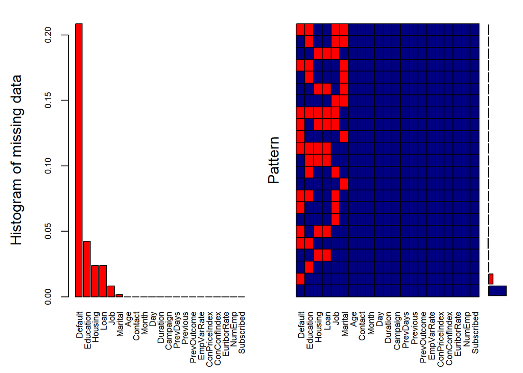

```
##
##  Variables sorted by number of missings:
##       Variable     Count
##        Default 0.2086333
##      Education 0.0423000
##        Housing 0.0239000
##           Loan 0.0239000
##            Job 0.0083000
##        Marital 0.0018000
##            Age 0.0000000
##        Contact 0.0000000
##          Month 0.0000000
##            Day 0.0000000
##       Duration 0.0000000
##       Campaign 0.0000000
##       PrevDays 0.0000000
##       Previous 0.0000000
##    PrevOutcome 0.0000000
##     EmpVarRate 0.0000000
##  ConPriceIndex 0.0000000
##   ConConfIndex 0.0000000
##    EuriborRate 0.0000000
##         NumEmp 0.0000000
##     Subscribed 0.0000000
```

```r
aggr_plot <- aggr(market_data, col=c('navyblue','red'), numbers=TRUE, sortVars=TRUE, labels=names(market_data),
                  cex.axis=.7, gap=3, ylab=c("Histogram of missing data","Pattern"))
```

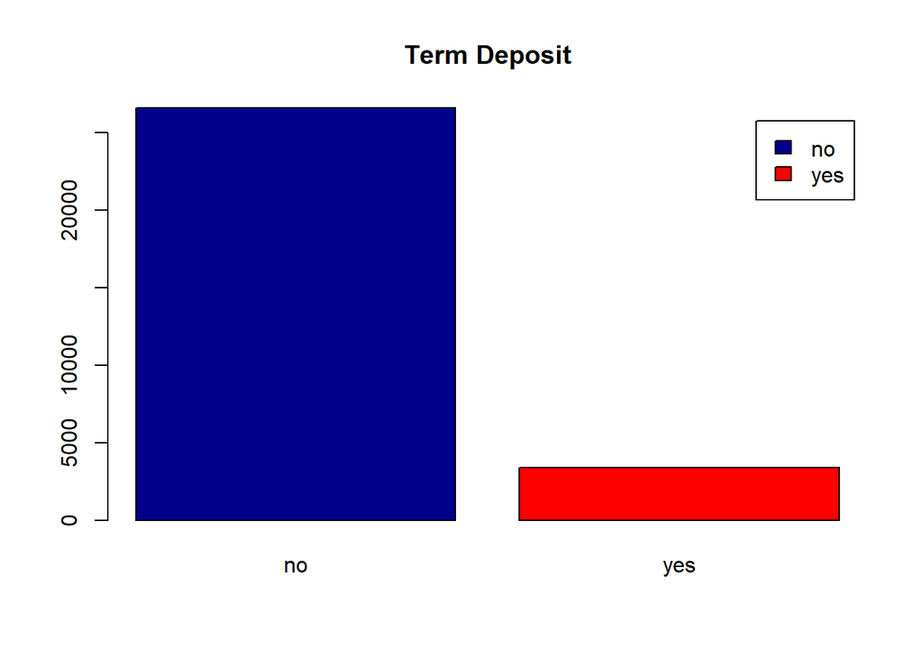

```r
cols <- c("darkblue","red")
counts <- table(market_data$Subscribed)
barplot(counts,col=cols,legend = rownames(counts), main = "Term Deposit")
```

3b : So for this dataset we face only the missing value problem, which can be solved by imputation method We will impute these missing values using MICE package

```r
market_data_imp<-mice(market_data)
mktData<-complete(market_data_imp)
```

3c : check again if missing values exist

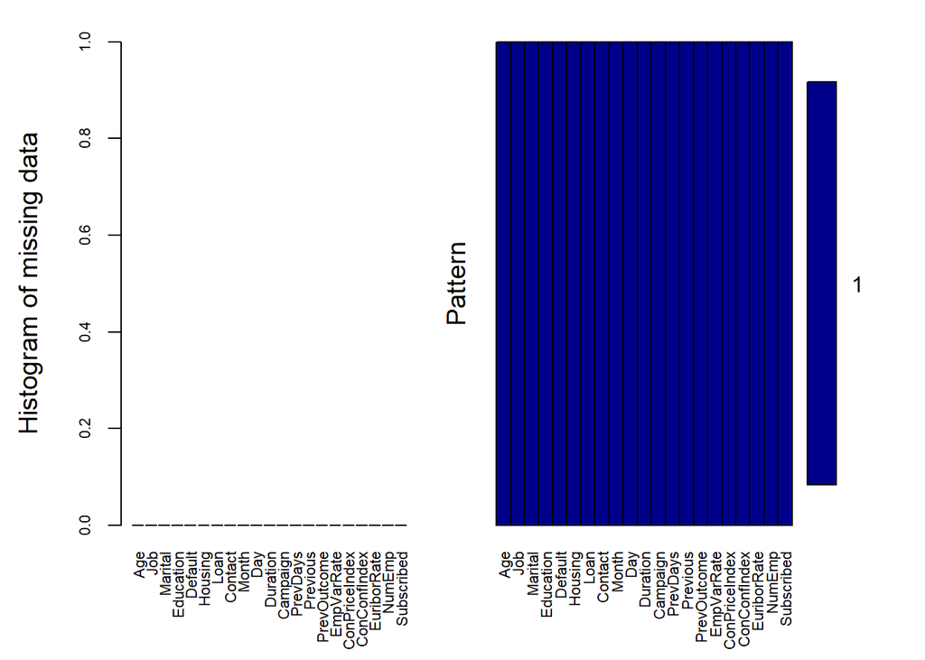

```
##
##  Variables sorted by number of missings:
##       Variable Count
##            Age     0
##            Job     0
##        Marital     0
##      Education     0
##        Default     0
##        Housing     0
##           Loan     0
##        Contact     0
##          Month     0
##            Day     0
##       Duration     0
##       Campaign     0
##       PrevDays     0
##       Previous     0
##    PrevOutcome     0
##     EmpVarRate     0
##  ConPriceIndex     0
##   ConConfIndex     0
##    EuriborRate     0
##         NumEmp     0
##     Subscribed     0
```

```r
aggr_plot <- aggr(mktData, col=cols, numbers=TRUE, sortVars=TRUE, labels=names(market_data), cex.axis=.7, gap=3, ylab=c("Histogram of missing data","Pattern"))
```

No missing values observed Checking the dimensions and summary after cleaning

```r
dim(mktData)      #dimension of the dataset
```

```
## [1] 30000    21
```

```r
summary(mktData) #summary of the dataset
```

```
##       Age                 Job           Marital             Education
##  Min.   :17.00   admin      :7691   divorced: 3351   university  :9143
##  1st Qu.:32.00   blue-collar:6796   married :18198   highschool  :7161
##  Median :38.00   technician :4922   single  : 8451   basic9y     :4681
##  Mean   :40.03   services   :2912   unknown :    0   professional:3970
##  3rd Qu.:47.00   management :2099                    basic4y     :3294
##  Max.   :98.00   retired    :1286                    basic6y     :1724
##                  (Other)    :4294                    (Other)     :  27
##     Default         Housing           Loan            Contact
##  no     :29998   no     :13902   no     :25300   cellular :19094
##  unknown:    0   unknown:    0   unknown:    0   telephone:10906
##  yes    :    2   yes    :16098   yes    : 4700
##
##
##
##
##      Month       Day          Duration         Campaign
##  may    :9988   fri:5739   Min.   :   0.0   Min.   : 1.000
##  jul    :5299   mon:6190   1st Qu.: 103.0   1st Qu.: 1.000
##  aug    :4479   thu:6255   Median : 179.0   Median : 2.000
##  jun    :3793   tue:5918   Mean   : 258.1   Mean   : 2.544
##  nov    :3037   wed:5898   3rd Qu.: 320.0   3rd Qu.: 3.000
##  apr    :1911              Max.   :4918.0   Max.   :56.000
##  (Other):1493
##     PrevDays        Previous           PrevOutcome      EmpVarRate
##  Min.   :  0.0   Min.   :0.0000   failure    : 3073   Min.   :-3.40000
##  1st Qu.:999.0   1st Qu.:0.0000   nonexistent:25942   1st Qu.:-1.80000
##  Median :999.0   Median :0.0000   success    :  985   Median : 1.10000
##  Mean   :962.8   Mean   :0.1707                       Mean   : 0.08312
##  3rd Qu.:999.0   3rd Qu.:0.0000                       3rd Qu.: 1.40000
##  Max.   :999.0   Max.   :6.0000                       Max.   : 1.40000
##
##  ConPriceIndex    ConConfIndex    EuriborRate        NumEmp
##  Min.   :92.20   Min.   :-50.8   Min.   :0.634   Min.   :4964
##  1st Qu.:93.08   1st Qu.:-42.7   1st Qu.:1.344   1st Qu.:5099
##  Median :93.75   Median :-41.8   Median :4.857   Median :5191
##  Mean   :93.57   Mean   :-40.5   Mean   :3.625   Mean   :5167
##  3rd Qu.:93.99   3rd Qu.:-36.4   3rd Qu.:4.961   3rd Qu.:5228
##  Max.   :94.77   Max.   :-26.9   Max.   :5.045   Max.   :5228
##
##  Subscribed
##  no :26603
##  yes: 3397
##
##
##
##
##
```

25942/30000 = 86.47% of the time outcome of previous marketing campaign is unknown. Duration seems to have lot more variation, it may be a good predictor Data is very imbalanced, only 11.32% yes in outcome.

Step 4 : Do some Exploratory Analysis

4a : plot all individual variables versus the Subscribed

Basic visualization for continuous variables

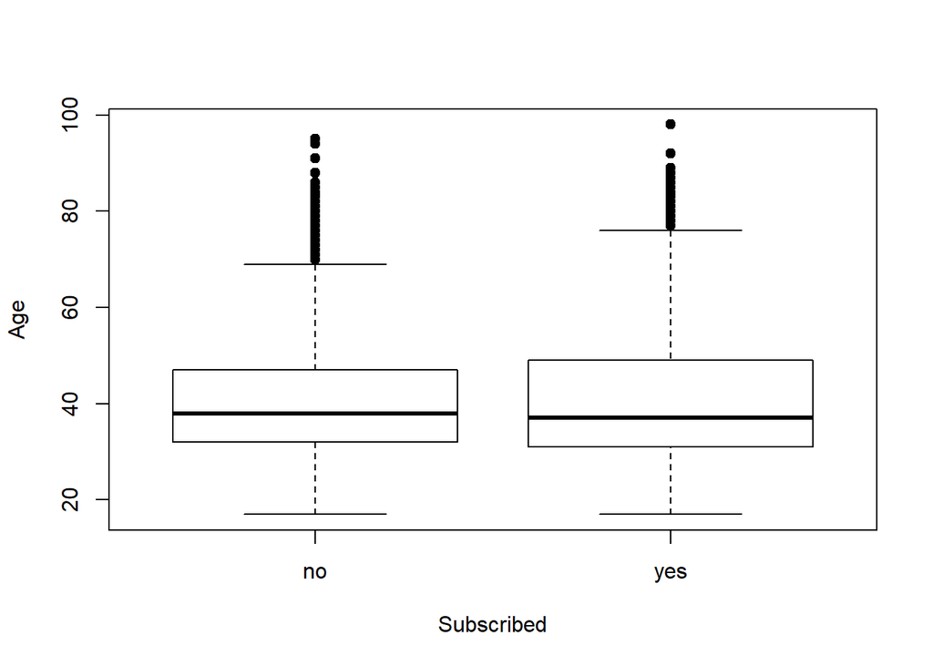

```r
plot(mktData$Subscribed, mktData$Age, xlab="Subscribed",
     ylab="Age", pch = 19, col = cols[as.numeric(mktData$Age)])
```

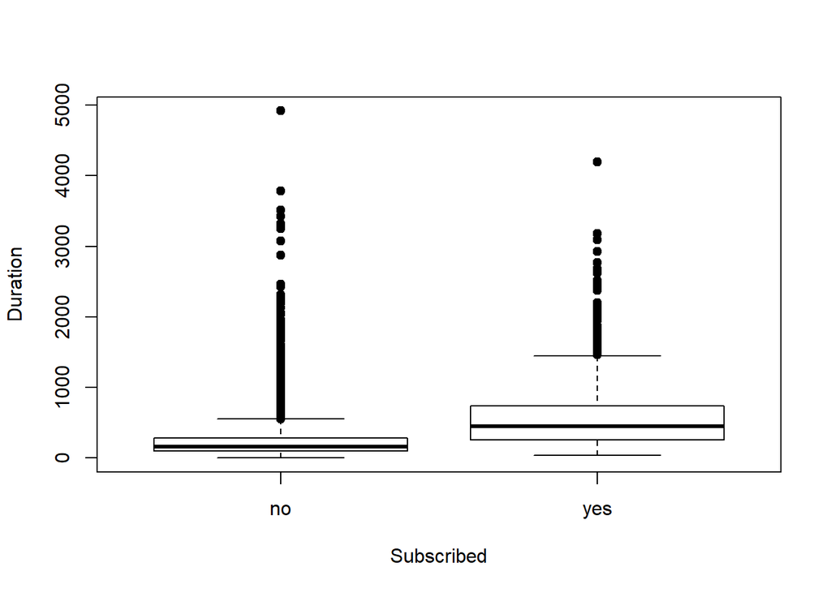

```r
plot(mktData$Subscribed, mktData$Duration, xlab="Subscribed",
     ylab="Duration", pch = 19, col = cols[as.numeric(mktData$Duration)])
```

Higher median duration for instances of Subscribed “yes” compared to “no”

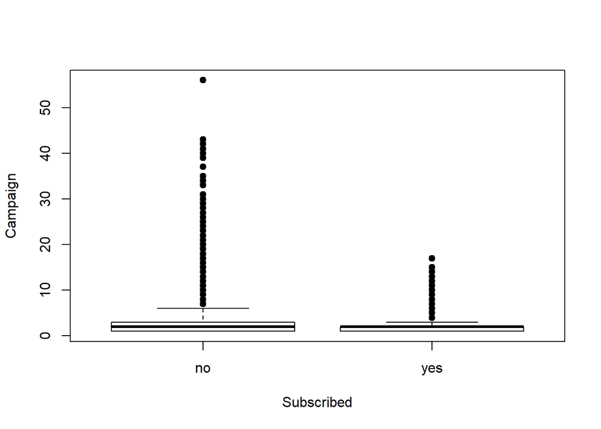

```r
plot(mktData$Subscribed, mktData$Campaign, xlab="Subscribed",
     ylab="Campaign", pch = 19, col = cols[as.numeric(mktData$Campaign)])
```

Campaign variable have the same median for both “no” and “yes” of Subscribed variable.

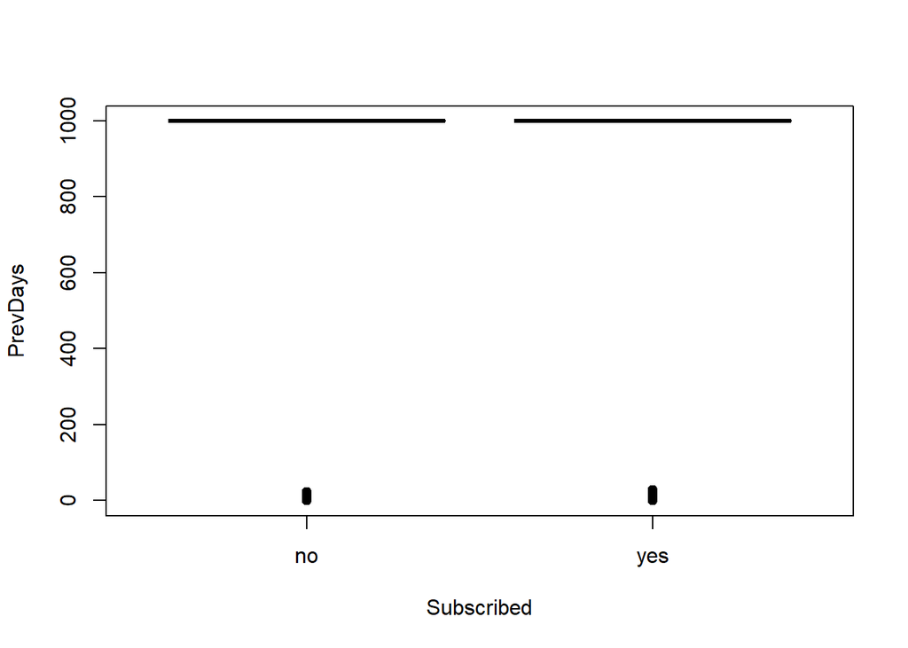

```r
plot(mktData$Subscribed, mktData$PrevDays, xlab="Subscribed",
     ylab="PrevDays", pch = 19, col = cols[as.numeric(mktData$PrevDays)])
```

PrevDays variable have the same median for both “no” and “yes” of Subscribed variable.

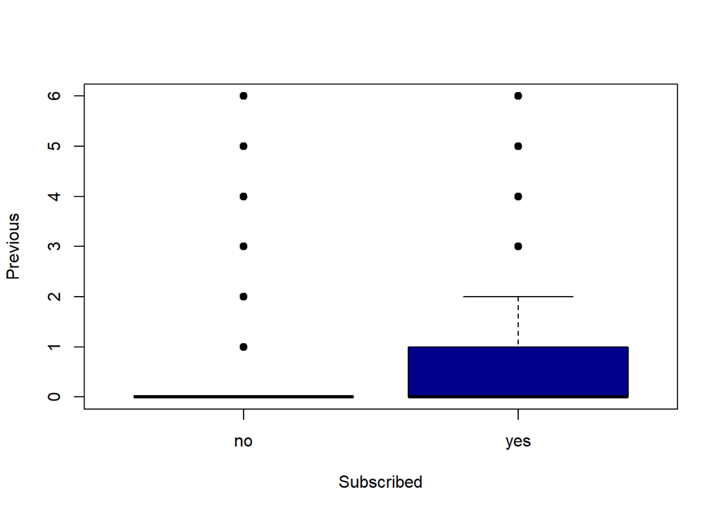

```r
plot(mktData$Subscribed, mktData$Previous, xlab="Subscribed",
     ylab="Previous", pch = 19, col = cols[as.numeric(mktData$Previous)])
```

Previous variable have the same median for both “no” and “yes” of Subscribed variable.

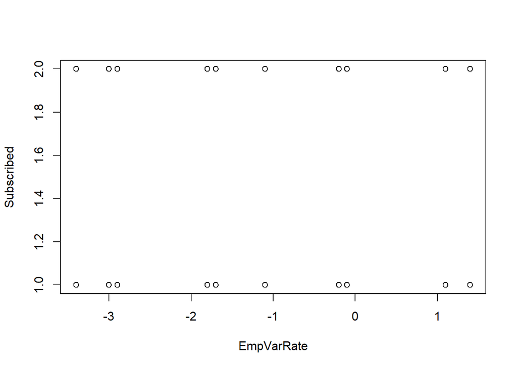

```r
plot(mktData$EmpVarRate, mktData$Subscribed, ylab="Subscribed", xlab="EmpVarRate")
```

EmpVarRate variables dont seem to provide a clear path to distuinguish the Subscribed variable at the first sight

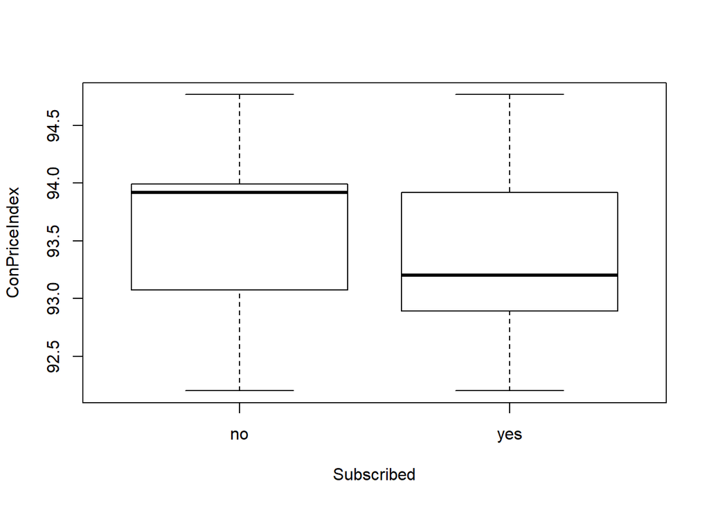

```r
plot(mktData$Subscribed, mktData$ConPriceIndex, xlab="Subscribed",
     ylab="ConPriceIndex", pch = 19, col = cols[as.numeric(mktData$ConPriceIndex)])
```

Higher median ConPriceIndex for instances of Subscribed “no” compared to “yes”

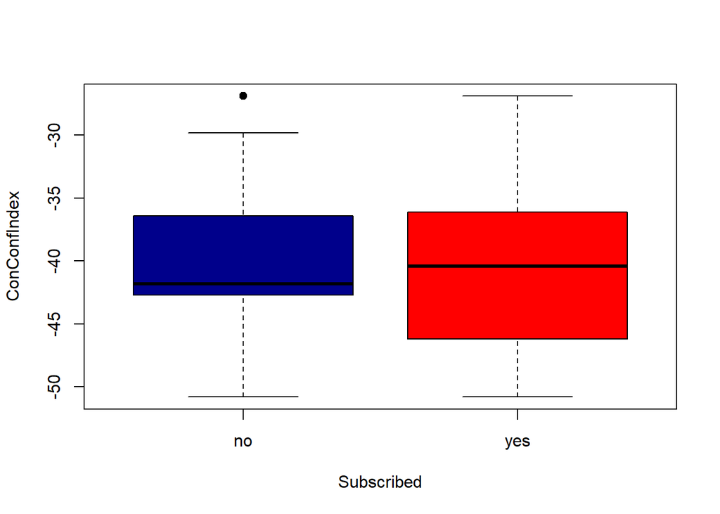

```r
plot(mktData$Subscribed, mktData$ConConfIndex, xlab="Subscribed",
     ylab="ConConfIndex", pch = 19, col = cols[as.numeric(mktData$ConConfIndex)])
```

Slightly higher median ConConfIndex for instances of Subscribed “yes” compared to “no”

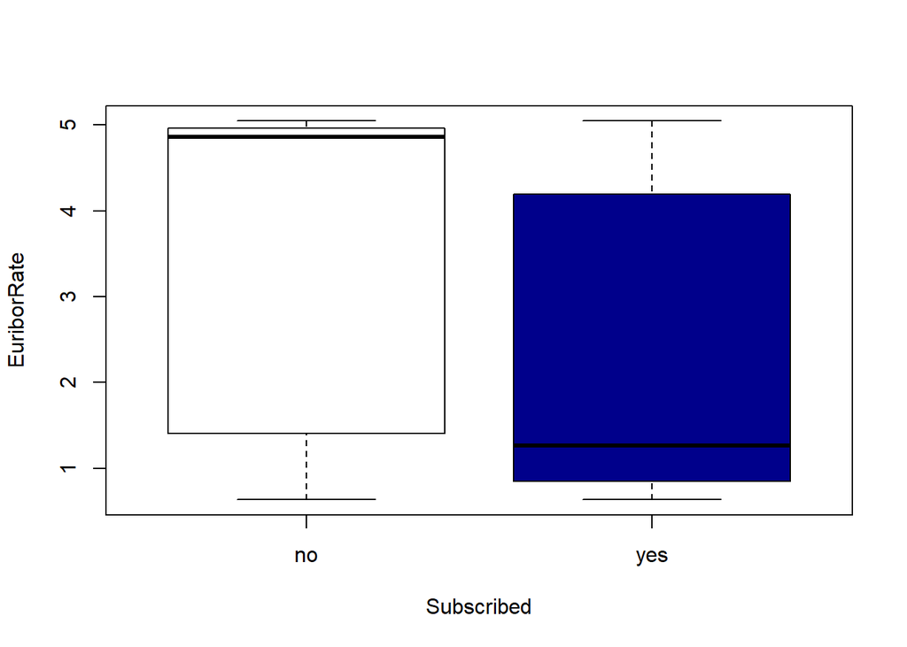

```r
plot(mktData$Subscribed, mktData$EuriborRate, xlab="Subscribed",
     ylab="EuriborRate", pch = 19, col = cols[as.numeric(mktData$EuriborRate)])
```

Relatively higher median EuriborRate for instances of Subscribed “no” compared to “yes”

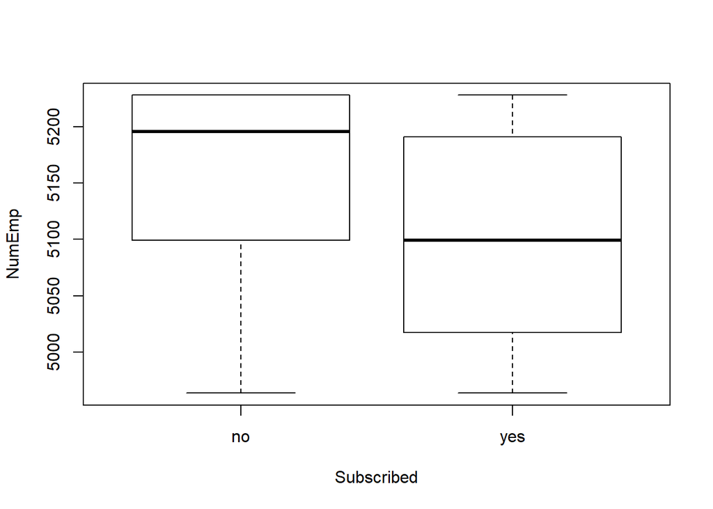

```r
plot(mktData$Subscribed, mktData$NumEmp, xlab="Subscribed",
     ylab="NumEmp", pch = 19, col = cols[as.numeric(mktData$NumEmp)])
```

Slightly higher median number of employees for the case “no”(~5200) compared to “yes”(~5100) of Subscribed variable

Basic visualization for categorical variables

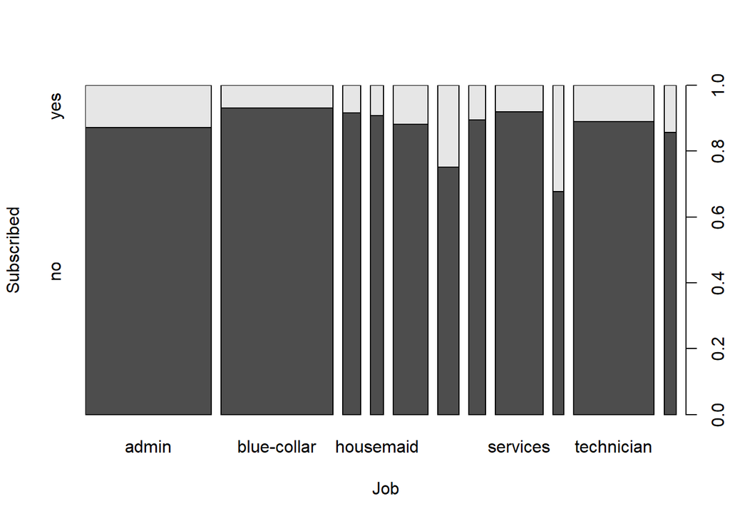

```r
plot(mktData$Job, mktData$Subscribed, ylab="Subscribed", xlab="Job")
```

The Job categories are namely admin, blue-collar,entrepreneur, housemaid, management, retired, self-employed,services, student, technician,unemployed,unknown As observed from the plot, retired and student categories are more likely to say yes to Subscribing the Term Deposit The other categories from Job variable are generally have the similar effect on Subscribed variable outcome

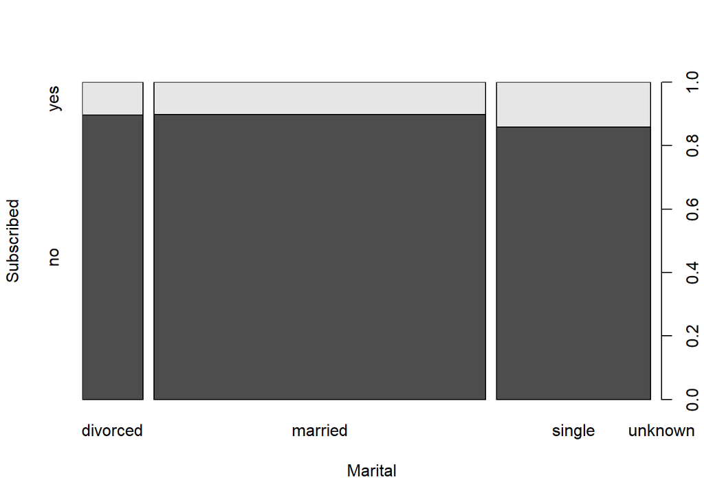

```r
plot(mktData$Marital, mktData$Subscribed, ylab="Subscribed", xlab="Marital")
```

single people are more likely to Subscribe divorced or married people doesnt seem to make any difference in the Subscribed variable

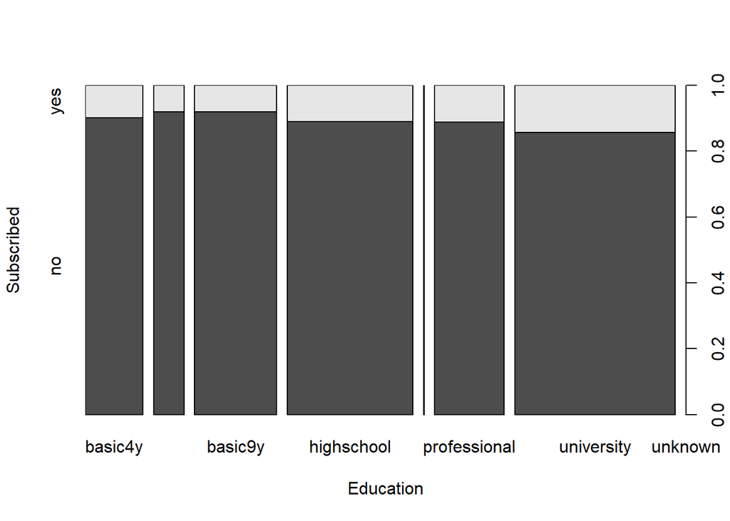

```r
plot(mktData$Education, mktData$Subscribed, ylab="Subscribed", xlab="Education")
```

University students are slighly more likely to subscribe compared to other levels. This seems reasonable as they might have started earning from the part time jobs during the university period Illiterate people who are smaller in proportion and all of them are not likely to subscribe

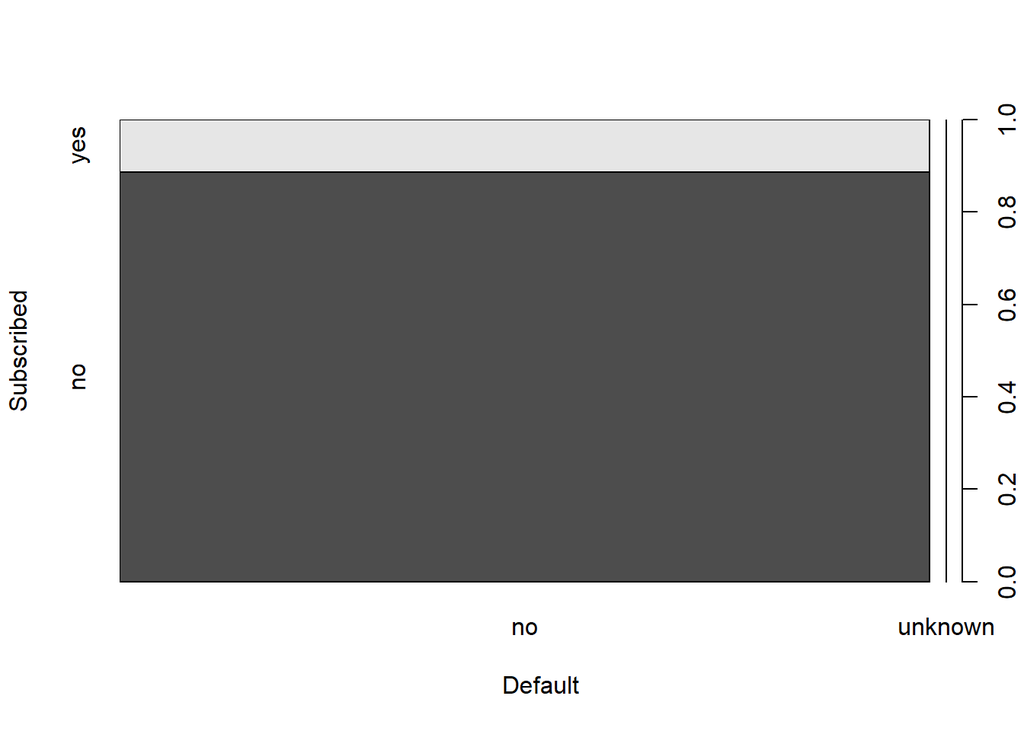

```r
plot(mktData$Default, mktData$Subscribed, ylab="Subscribed", xlab="Default")
```

Here it can be observed that most of the people did not have Credit in Default before so Default doesnt seem to make any difference in Subscribed variable

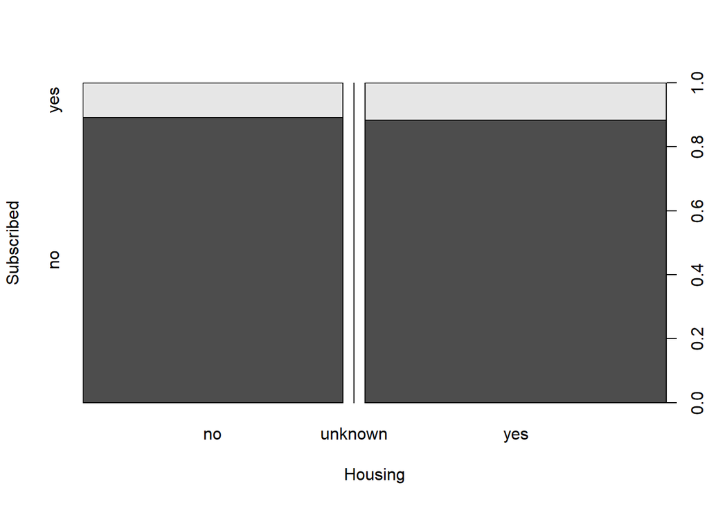

```r
plot(mktData$Housing, mktData$Subscribed, ylab="Subscribed", xlab="Housing")
```

Housing doesnt seem to make any difference in Subscribed variable

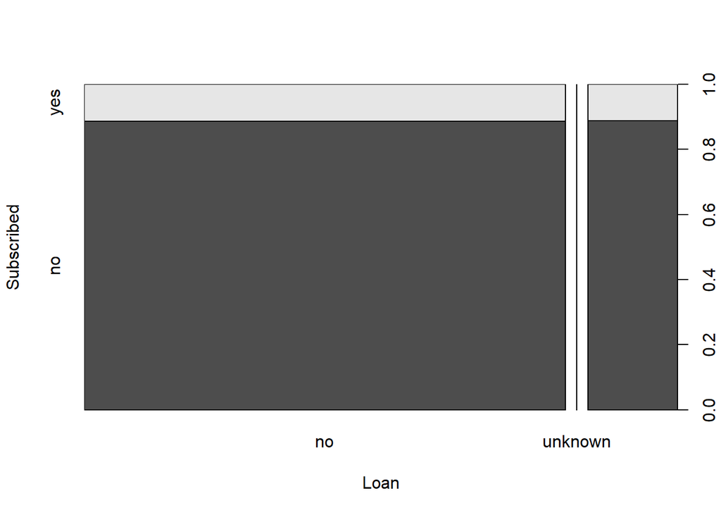

```r
plot(mktData$Loan, mktData$Subscribed, ylab="Subscribed", xlab="Loan")
```

Loan doesnt seem to make any difference in Subscribed variable

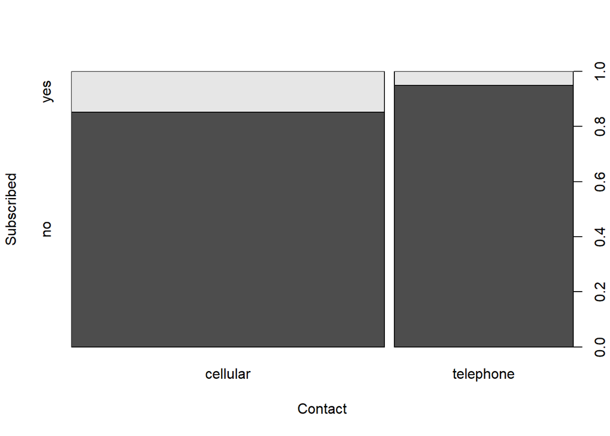

```r
plot(mktData$Contact, mktData$Subscribed, ylab="Subscribed", xlab="Contact")
```

Instances with cellular contact are more likely to subscribe

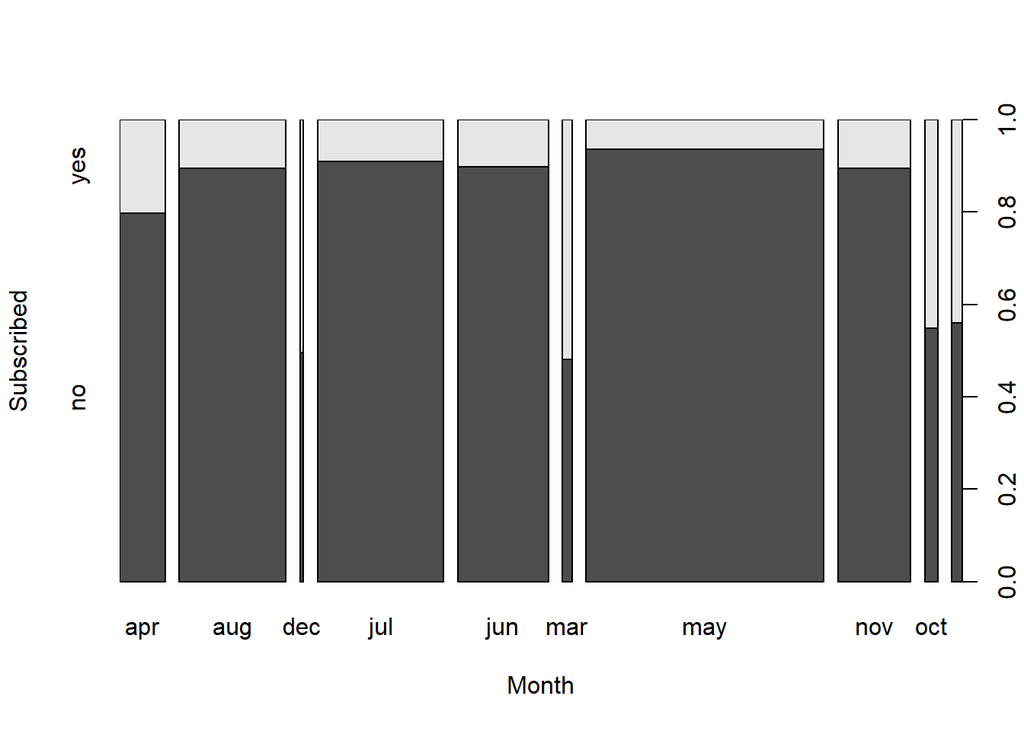

```r
plot(mktData$Month, mktData$Subscribed, ylab="Subscribed", xlab="Month")
```

apr, aug, jul, june, may, nov are less likely to subscibe while dec, mar, oct and others are more likely to subscribe

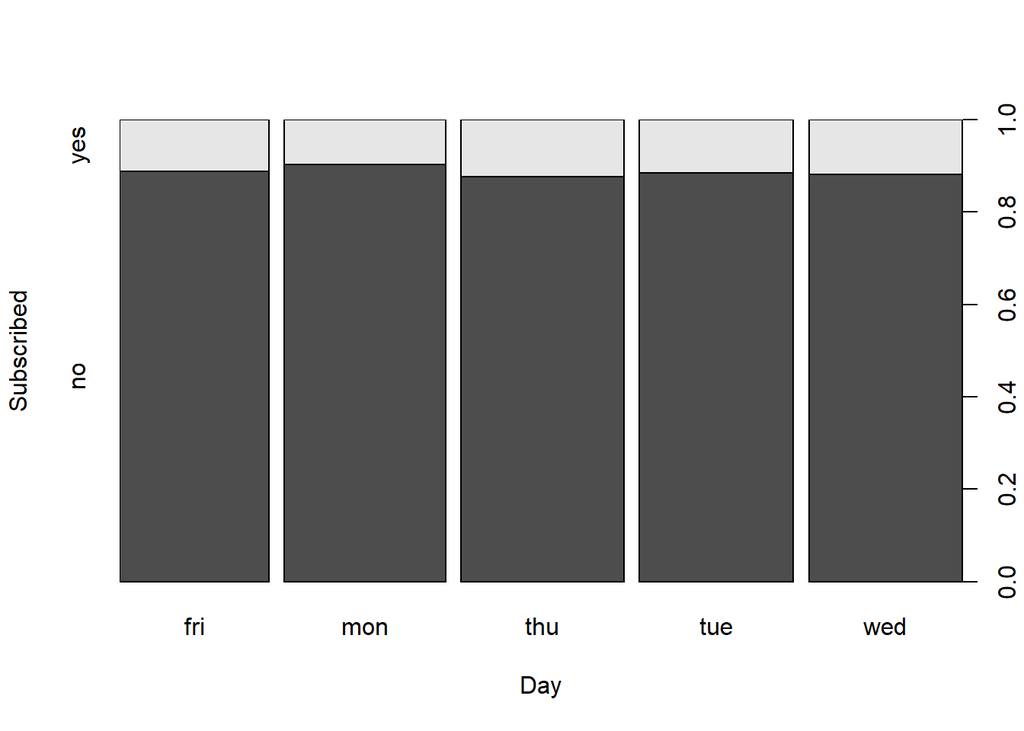

```r
plot(mktData$Day, mktData$Subscribed, ylab="Subscribed", xlab="Day")
```

Only slight differences observed, therefore might not be much of difference to Subscribed variable

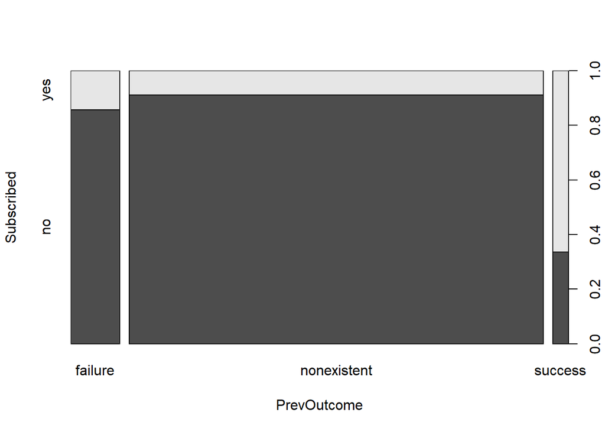

```r
plot(mktData$PrevOutcome, mktData$Subscribed, ylab="Subscribed", xlab="PrevOutcome")
```

Clearly, people with PrevOutcome being a success are more likely to subscribe again

Variables like PrevOutcome, Month, Education, Marital, Job seem to be of some significance. It will be determined in the steps ahead.

Checking the dimensions after cleaning

```r
dim(mktData)     #dimension of the dataset
```

```
## [1] 30000    21
```

Split into Train and Validation sets Training Set : Validation Set = 70 : 30 (random)

```r
train <- sample(nrow(mktData), 0.7*nrow(mktData), replace = FALSE)
mktTrain <- mktData[train,]
mktValid <- mktData[-train,]
```

Dimension of the new split datasets

```r
dim(mktTrain)
```

```
## [1] 21000    21
```

```r
dim(mktValid)
```

```
## [1] 9000   21
```

### Problem 1

Build an optimal tree-based classification model for `Subscribed` vs the **Personal Profile** and **Financial Profile** of a person. Check the relevant accuracy parameters of your model, and use it to predict `Subscribed` in the `assign2_MarketingPred.csv`.

- Identify the top three important variables in this case.
- Why are these important? Justify in terms of the Business.
- How would you influence `Subscribed` using these variables?

Basic Decision Trees Model building and prediction

Step 5 : Build a Decision Tree (Subscribed vs the respective variables)

5a : fit a decision tree on Subscribed vs Personal Profile and Financial varibles

```r
treeFit <- tree(Subscribed ~ (Age+Job+Marital+Education+Contact+Default+Housing+Loan), data = mktTrain)
```

5b : display the decision tree

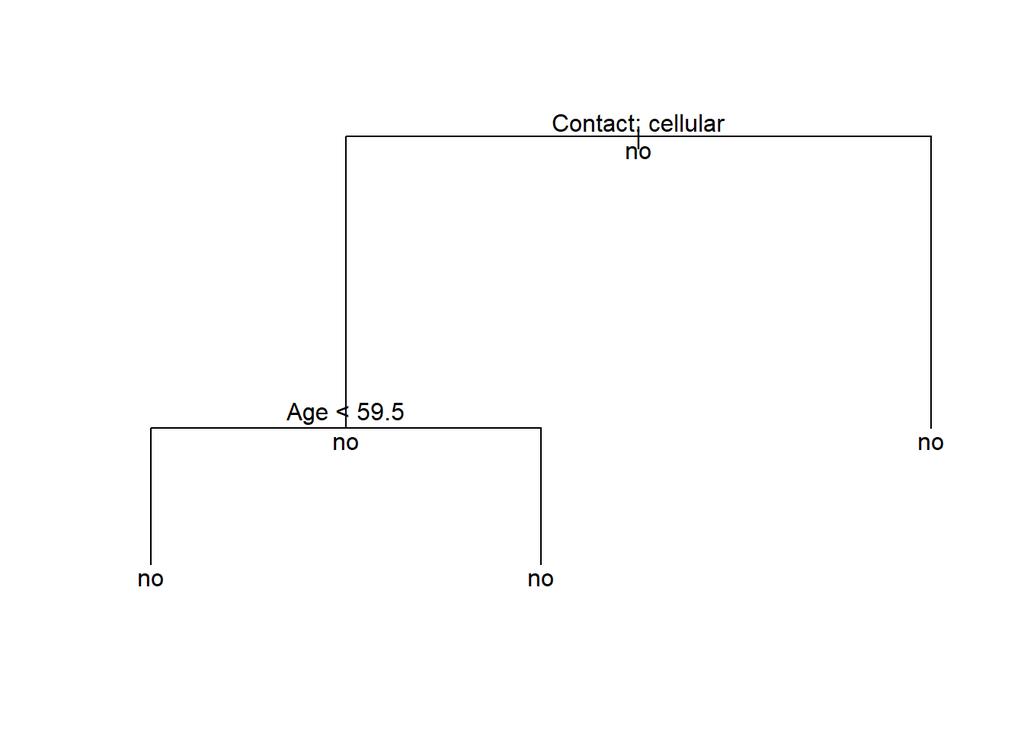

```r
plot(treeFit)
text(treeFit, pretty = FALSE, all = TRUE)
```

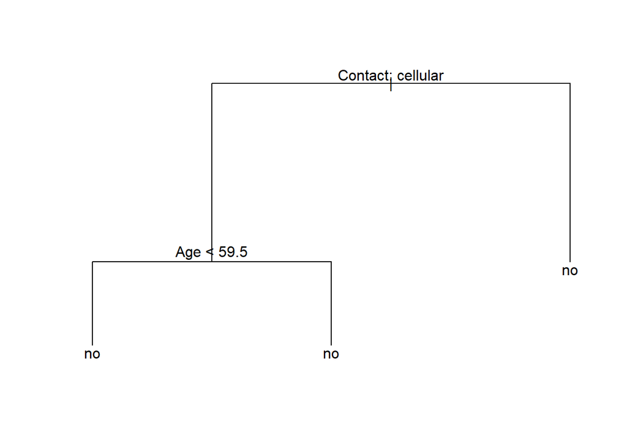

```r
plot(treeFit)
text(treeFit, pretty = FALSE)
```

5c : print the complete tree structure

```r
treeFit
```

```
## node), split, n, deviance, yval, (yprob)
##       * denotes terminal node
##
## 1) root 21000 14870.0 no ( 0.88633 0.11367 )
##   2) Contact: cellular 13360 11270.0 no ( 0.85045 0.14955 )
##     4) Age < 59.5 12862 10350.0 no ( 0.86153 0.13847 ) *
##     5) Age > 59.5 498   682.1 no ( 0.56426 0.43574 ) *
##   3) Contact: telephone 7640  3074.0 no ( 0.94908 0.05092 ) *
```

5d : view the summary of the tree

```r
summary(treeFit)
```

```
##
## Classification tree:
## tree(formula = Subscribed ~ (Age + Job + Marital + Education +
##     Contact + Default + Housing + Loan), data = mktTrain)
## Variables actually used in tree construction:
## [1] "Contact" "Age"
## Number of terminal nodes:  3
## Residual mean deviance:  0.6716 = 14100 / 21000
## Misclassification error rate: 0.1137 = 2387 / 21000
```

5e : what is the “complexity” of the model? How many nodes? Number of terminal nodes: 3

5g : which variable is most significant? why? It seems that Contact is most significant (first split)

Step 6 : Predict classes using the Decision Tree Model

Predict using the tree model on training and validation data

```r
predTrainData <- predict(treeFit, mktTrain, type = "class")
predValidData <- predict(treeFit, mktValid, type = "class")
```

Classification accuracy on Train data

```r
mean(predTrainData == mktTrain$Subscribed)
```

```
## [1] 0.8863333
```

Classification accuracy on Validation data

```r
mean(predValidData == mktValid$Subscribed)
```

```
## [1] 0.8877778
```

Predict using the tree model

```r
predData <- predict(treeFit, mktData, type = "class")
```

Confusion matrix

```r
table(mktData$Subscribed, predData)
```

```
##      predData
##          no   yes
##   no  26603     0
##   yes  3397     0
```

Classification accuracy

```r
mean(predData == mktData$Subscribed)
```

```
## [1] 0.8867667
```

Can’t interpret False Positive or False Negative directly Every diagonal element is Correct, and non-diagonal Wrong

what is the rate of misclassification error? Misclassification Rate = 1 - Accurate Classification Rate Accurate Classification Rate = (26603) / 30000 = 0.8867667 Misclassification Rate = 1 - 0.8867667 = 0.1132

Step 7: Tree Model - Performance measures for Prediction

7a : Confusion matrix

```r
cm <- table(mktData$Subscribed, predData)
TP <- cm[2,2] #True Positive (Good predicted as Good)
TN <- cm[1,1] #True Negative (Bad predicted as Bad)
FP <- cm[1,2] #False Positive (Bad predicted as Good) -- Type I error
FN <- cm[2,1] #False Negative (Good predicted as Bad) -- Type II error
```

7b : Classification Accuracy

```r
(TN + TP) / (TN + TP + FN + FP)   #Correct Classification / Total
```

```
## [1] 0.8867667
```

```r
mean(predData == mktData$Subscribed)  #Classification accuracy (alt.)
```

```
## [1] 0.8867667
```

7c : False Positive Rate (fpr) / Type I error / 1 - Specificity

```r
FP / (TN + FP)     #False Positive / Total Negative
```

```
## [1] 0
```

7d : True Positive Rate (tpr) / 1 - Type II error / Sensitivity

```r
TP / (TP + FN)     #True Positive / Total Positive
```

```
## [1] 0
```

7e : Predict probabilities using the tree model

```r
probData <- predict(treeFit, mktData, type = "vector")
```

Convert probabilities to prediction with threshold 0.5

```r
threshold <- 0.5
predData <- rep("no", nrow(mktData))
predData[probData[,2] > threshold] = "yes"
predData <- as.factor(predData)
table(mktData$Subscribed, predData)
```

```
##      predData
##          no
##   no  26603
##   yes  3397
```

Convert probabilities to prediction with threshold 0.9

```r
threshold <- 0.9

predData <- rep("no", nrow(mktData))
predData[probData[,2] > threshold] = "yes"
predData <- as.factor(predData)

table(mktData$Subscribed, predData)
```

```
##      predData
##          no
##   no  26603
##   yes  3397
```

Convert probabilities to prediction with threshold 0.2

```r
threshold <- 0.2

predData <- rep("no", nrow(mktData))
predData[probData[,2] > threshold] = "yes"
predData <- as.factor(predData)

table(mktData$Subscribed, predData)
```

```
##      predData
##          no   yes
##   no  26194   409
##   yes  3092   305
```

Convert probabilities to prediction with threshold 0.4

```r
threshold <- 0.4

predData <- rep("no", nrow(mktData))
predData[probData[,2] > threshold] = "yes"
predData <- as.factor(predData)

table(mktData$Subscribed, predData)
```

```
##      predData
##          no   yes
##   no  26194   409
##   yes  3092   305
```

threshold 0.2 to 0.4 have the same number of False Positives and True Positives

```r
cm <- table(mktData$Subscribed, predData)
cm[1,2] / (cm[1,1] + cm[1,2])     #False Positive Rate (fpr)
```

```
## [1] 0.01537421
```

```r
cm[2,2] / (cm[2,2] + cm[2,1])     #True Positive Rate (tpr)
```

```
## [1] 0.0897851
```

Convert probabilities to prediction with threshold 0.1

```r
threshold <- 0.1
predData <- rep("no", nrow(mktData))
predData[probData[,2] > threshold] = "yes"
predData <- as.factor(predData)

table(mktData$Subscribed, predData)
```

```
##      predData
##          no   yes
##   no  10342 16261
##   yes   564  2833
```

```r
cm <- table(mktData$Subscribed, predData)
cm[1,2] / (cm[1,1] + cm[1,2])     #False Positive Rate (fpr)
```

```
## [1] 0.6112469
```

```r
cm[2,2] / (cm[2,2] + cm[2,1])     #True Positive Rate (tpr)
```

```
## [1] 0.8339712
```

Higher tpr, however, the fpr is also higher for threshold with 0.1 compared to threshold between 0.2 to 0.4

Step 9 : Build a Bagging Model on the data set Subscribed vs Personal Profile and Financial varibles

```r
rFit <- randomForest(Subscribed ~ (Age+Job+Marital+Education+Contact+Default+Housing+Loan),                      #formula
                       data = mktTrain,                  #data set
                       ntree = 500,                     #number of trees
                       mtry = 3,                        #variables for split
                       importance = TRUE)               #importance recorded
rFit
```

```
##
## Call:
##  randomForest(formula = Subscribed ~ (Age + Job + Marital + Education +      Contact + Default + Housing + Loan), data = mktTrain, ntree = 500,      mtry = 3, importance = TRUE)
##                Type of random forest: classification
##                      Number of trees: 500
## No. of variables tried at each split: 3
##
##         OOB estimate of  error rate: 11.46%
## Confusion matrix:
##        no yes class.error
## no  18484 129  0.00693064
## yes  2278 109  0.95433599
```

prediction on train set & classification accuracy on train set

```r
predTrain <- predict(rFit, mktTrain, type = "class")
mean(predTrain == mktTrain$Subscribed)
```

```
## [1] 0.8964286
```

prediction on validation set & classification accuracy on test set

```r
predValid <- predict(rFit, mktValid, type = "class")
mean(predValid == mktValid$Subscribed)
```

```
## [1] 0.8883333
```

Predict using the bagging model

```r
predData <- predict(rFit, mktData, type = "class")
```

Confusion matrix

```r
table(mktData$Subscribed, predData)
```

```
##      predData
##          no   yes
##   no  26526    77
##   yes  3103   294
```

Classification accuracy

```r
acc <- mean(predData == mktData$Subscribed)
print(paste('Accuracy',acc))
```

```
## [1] "Accuracy 0.894"
```

mtry can be 3 according to the square root of the total number of variables, 8. 2 was providing a better accuracy on the validation set. Increasing the number of trees in the random forest allows to only slightly increase accuracy, so fixing trees to 500 due to only slight increase

Bagging gives variable importance for free, depending on the splits importance of the variables in the model (values)

```r
importance(rFit)
```

```
##                  no        yes MeanDecreaseAccuracy MeanDecreaseGini
## Age       43.812340  40.766074            66.106875     494.55822005
## Job       56.135243  -9.638618            60.651648     211.30301393
## Marital   19.260336   8.323442            25.256927      67.33204574
## Education 52.807864 -14.594186            51.776867     138.54472355
## Contact   15.553201  13.965408            21.811618      90.38316483
## Default    0.000000   0.000000             0.000000       0.08013841
## Housing    6.164945   3.142105             6.880379      56.09795541
## Loan      -4.346095  -1.769861            -4.673994      46.43812131
```

importance of the variables in the model can be visualised on the graph above

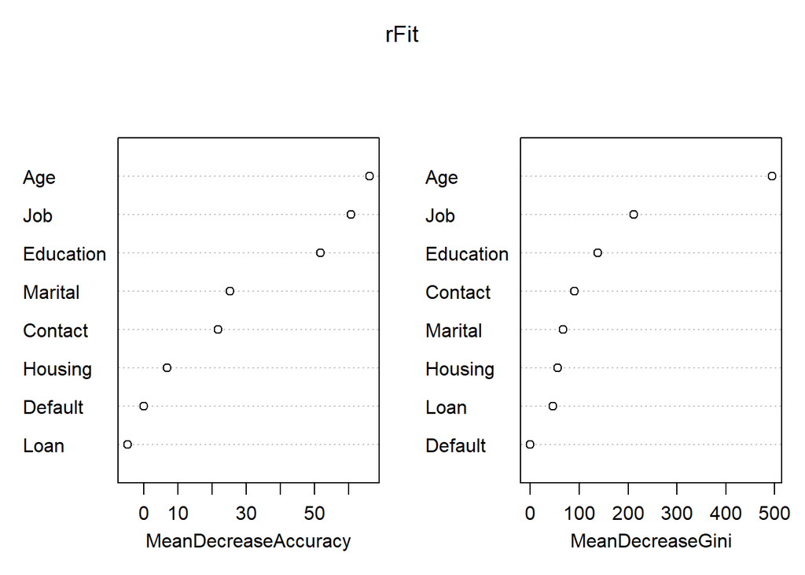

```r
varImpPlot(rFit)       #importance of the variables in the model (visual)
```

- Identify the top three important variables in this case. Job, Education & Age proved to be the top variables. Removing these variables could result in a significant decrease in accuracy.
- Why are these important? Justify in terms of the Business. * How would you influence `Subscribed` using these variables? These are basic background information of the customers which clearly say a lot on how they behave For example, Job - as mentioned previously in the analysis, the retired and student etc are more likely to subscribe. Hence, Agents may target clients of job category of retired and student etc as these set of people look for safe deposit of their savings with fixed returns.

Step 10 : Use the model to predict `Subscribed` in the `assign2_MarketingPred.csv`.

```r
mktTest <- read.csv("assign2_MarketingPred.csv", header = TRUE)
levels(mktTest$Age) <- levels(mktTrain$Age)
levels(mktTest$Job) <- levels(mktTrain$Job)
levels(mktTest$Marital) <- levels(mktTrain$Marital)
levels(mktTest$Education) <- levels(mktTrain$Education)
levels(mktTest$Contact) <- levels(mktTrain$Contact)
levels(mktTest$Default) <- levels(mktTrain$Default)
levels(mktTest$Housing) <- levels(mktTrain$Housing)
levels(mktTest$Loan) <- levels(mktTrain$Loan)
```

Showing the result of the prediction on test set

```r
predTest <- predict(rFit, mktTest, type = "class")
summary(predTest)
```

```
##  no yes
## 990  10
```

```r
testdata_p1 <- mktTest
testdata_p1$Subscribed<-predTest
testdata_p1
```

```
##      Age           Job  Marital    Education Default Housing    Loan
## 1     29  entrepreneur  married      basic6y      no      no      no
## 2     25   blue-collar   single      basic9y      no      no      no
## 3     37   blue-collar  married   illiterate      no      no      no
## 4     31    technician  married professional      no      no      no
## 5     37         admin  married professional      no      no      no
## 6     49     housemaid  married   illiterate      no     yes      no
## 7     48   blue-collar  married      basic9y      no      no      no
## 8     52    technician  married   illiterate      no      no      no
## 9     35    management  married professional      no     yes      no
## 10    34    management  married professional      no      no      no
## 11    26         admin   single   highschool      no     yes      no
## 12    43         admin  married professional unknown      no      no
## 13    50         admin  married   highschool unknown      no      no
## 14    30    technician   single   illiterate      no     yes      no
```

[output cut: 2988 more lines]

### Problem 2

Build an optimal tree-based classification model for `Subscribed` vs **Personal Profile**, **Financial Profile**, and **Campaign Data** corresponding to a person. Check the relevant accuracy parameters of your model, and use it to predict `Subscribed` in the `assign2_MarketingPred.csv`.

- Identify the top three important variables in this case.
- Why are these important? Justify in terms of the Business.
- How would you influence `Subscribed` using these variables?

Step 9 : Build a Bagging Model on the data set

```r
rFit <- randomForest(Subscribed ~ (Age+Job+Marital+Education+Contact+Default+Housing+Loan
                                   +Month+Day+Duration+Campaign+PrevDays+Previous+PrevOutcome),                      ##formula
                       data = mktTrain,                  #data set
                       ntree = 500,                     #number of trees
                       mtry = 4,                        #variables for split
                       importance = TRUE)               #importance recorded
rFit
```

```
##
## Call:
##  randomForest(formula = Subscribed ~ (Age + Job + Marital + Education +      Contact + Default + Housing + Loan + Month + Day + Duration +      Campaign + PrevDays + Previous + PrevOutcome), data = mktTrain,      ntree = 500, mtry = 4, importance = TRUE)
##                Type of random forest: classification
##                      Number of trees: 500
## No. of variables tried at each split: 4
##
##         OOB estimate of  error rate: 8.88%
## Confusion matrix:
##        no  yes class.error
## no  17981  632  0.03395476
## yes  1233 1154  0.51654797
```

prediction on train set & classification accuracy on train set

```r
predTrain <- predict(rFit, mktTrain, type = "class")
mean(predTrain == mktTrain$Subscribed)
```

```
## [1] 0.9983333
```

prediction on validation set & classification accuracy on test set

```r
predValid <- predict(rFit, mktValid, type = "class")
mean(predValid == mktValid$Subscribed)
```

```
## [1] 0.9073333
```

Predict using the bagging model

```r
predData <- predict(rFit, mktData, type = "class")
```

Confusion matrix

```r
table(mktData$Subscribed, predData)
```

```
##      predData
##          no   yes
##   no  26295   308
##   yes   563  2834
```

Classification accuracy

```r
acc <- mean(predData == mktData$Subscribed)
print(paste('Accuracy',acc))
```

```
## [1] "Accuracy 0.970966666666667"
```

mtry can be 4 according to the square root of the total number of variables, 15. 3 was providing a better accuracy on the validation set. Increasing the number of trees in the random forest allows to only slightly increase accuracy, so fixing trees to 500 due to only slight increase And definitely a lot more improvement in the classification accuracy, this means that some of the campaign data are actually important and we will find out more below

Bagging gives variable importance for free, depending on the splits importance of the variables in the model (values)

```r
importance(rFit)
```

```
##                      no        yes MeanDecreaseAccuracy MeanDecreaseGini
## Age          38.8076451  18.198491           42.7750654     4.708187e+02
## Job          31.5383819   1.583464           30.5146732     3.016160e+02
## Marital       5.5987141   7.267724            8.8307224     9.681505e+01
## Education    23.3996178   1.407342           23.1007750     1.952928e+02
## Contact      63.5764237  20.967789           65.1266708     6.963310e+01
## Default       0.0000000   0.000000            0.0000000     5.634814e-03
## Housing       0.8759307  -2.121461           -0.4453608     7.360050e+01
## Loan         -3.5781408  -4.533205           -5.5616174     5.061255e+01
## Month        95.9805764  56.432896          108.0439666     5.109735e+02
## Day          12.3384775   7.878587           14.0446423     2.509668e+02
## Duration    121.5061884 209.111655          202.4082555     1.336701e+03
## Campaign      0.9621759  10.802980            7.3842526     1.835063e+02
## PrevDays     27.9351779  34.642313           40.5231910     2.415753e+02
## Previous     16.6133154   8.163937           16.3696900     8.544789e+01
## PrevOutcome  23.7212752  12.499099           25.6332307     1.780489e+02
```

importance of the variables in the model can be visualised on the graph above

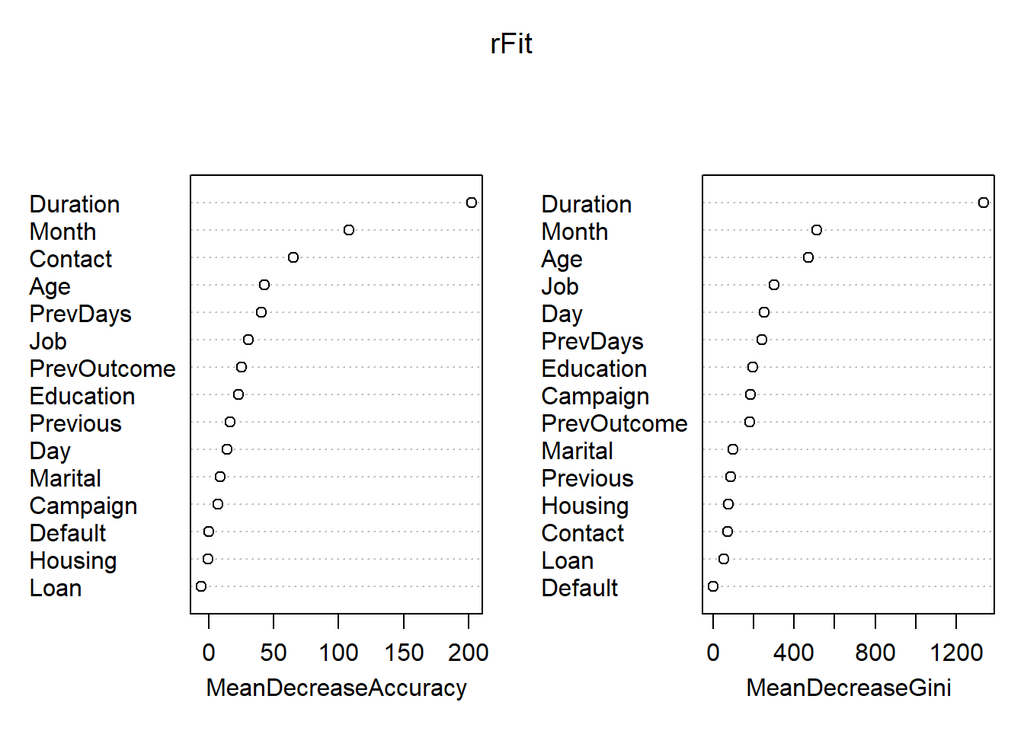

```r
varImpPlot(rFit)       #importance of the variables in the model (visual)
```

- Identify the top three important variables in this case. Duration, Month & Age proved to be the top variables. Removing these variables could result in a significant decrease in accuracy.
- Why are these important? Justify in terms of the Business. * How would you influence `Subscribed` using these variables? Duration is something that the bank can control “Duration” has positive effect on people saying “yes”. This is because the longer the conversations on the phone, the higher interest the customer will show to the term deposit. The Bank ought to focus on the potential clients who have significant call duration and moreover who have reacted emphatically amid the past campaign. The month in which the campaign is launched/carried out could affect Subscription rate as during festive periods, one is more likey to splurge. Age definitely is important, the higher the age, the more likely the customers are looking for securing a deposit for times of need. Hence banks can likely target the adults from age 30 onwards

Step 10 : Use the model to predict `Subscribed` in the `assign2_MarketingPred.csv`.

```r
mktTest <- read.csv("assign2_MarketingPred.csv", header = TRUE)
levels(mktTest$Age) <- levels(mktTrain$Age)
levels(mktTest$Job) <- levels(mktTrain$Job)
levels(mktTest$Marital) <- levels(mktTrain$Marital)
levels(mktTest$Education) <- levels(mktTrain$Education)
levels(mktTest$Contact) <- levels(mktTrain$Contact)
levels(mktTest$Default) <- levels(mktTrain$Default)
levels(mktTest$Housing) <- levels(mktTrain$Housing)
levels(mktTest$Loan) <- levels(mktTrain$Loan)
levels(mktTest$Month) <- levels(mktTrain$Month)
levels(mktTest$Day) <- levels(mktTrain$Day)
levels(mktTest$Duration) <- levels(mktTrain$Duration)
levels(mktTest$Campaign) <- levels(mktTrain$Campaign)
levels(mktTest$PrevDays) <- levels(mktTrain$PrevDays)
levels(mktTest$Previous) <- levels(mktTrain$Previous)
levels(mktTest$PrevOutcome) <- levels(mktTrain$PrevOutcome)
```

Showing the result of the prediction on test set

```r
predTest <- predict(rFit, mktTest, type = "class")
summary(predTest)
```

```
##  no yes
## 917  83
```

```r
testdata_p2 <- mktTest
testdata_p2$Subscribed<-predTest
testdata_p2
```

```
##      Age           Job  Marital    Education Default Housing    Loan
## 1     29  entrepreneur  married      basic6y      no      no      no
## 2     25   blue-collar   single      basic9y      no      no      no
## 3     37   blue-collar  married   illiterate      no      no      no
## 4     31    technician  married professional      no      no      no
## 5     37         admin  married professional      no      no      no
## 6     49     housemaid  married   illiterate      no     yes      no
## 7     48   blue-collar  married      basic9y      no      no      no
## 8     52    technician  married   illiterate      no      no      no
## 9     35    management  married professional      no     yes      no
## 10    34    management  married professional      no      no      no
## 11    26         admin   single   highschool      no     yes      no
## 12    43         admin  married professional unknown      no      no
## 13    50         admin  married   highschool unknown      no      no
## 14    30    technician   single   illiterate      no     yes      no
```

[output cut: 2988 more lines]

### Problem 3

Build an optimal tree-based classification model for `Subscribed` vs all variables, **Personal Profile**, **Financial Profile**, **Campaign Data**, **Demographic Info** corresponding to a person. Check the relevant accuracy parameters of your model, and use it to predict `Subscribed` in the `assign2_MarketingPred.csv`.

- Identify the top three important variables in this case.
- Why are these important? Justify in terms of the Business.
- How would you influence `Subscribed` using these variables?

Step 9 : Build a Bagging Model on the data set

```r
rFit <- randomForest(Subscribed ~ .,                      #formula
                     data = mktTrain,                  #data set
                     ntree = 500,                     #number of trees
                     mtry = 5,                        #variables for split
                     importance = TRUE)               #importance recorded
rFit
```

```
##
## Call:
##  randomForest(formula = Subscribed ~ ., data = mktTrain, ntree = 500,      mtry = 5, importance = TRUE)
##                Type of random forest: classification
##                      Number of trees: 500
## No. of variables tried at each split: 5
##
##         OOB estimate of  error rate: 8.56%
## Confusion matrix:
##        no  yes class.error
## no  17887  726   0.0390050
## yes  1072 1315   0.4490993
```

prediction on train set & classification accuracy on train set

```r
predTrain <- predict(rFit, mktTrain, type = "class")
mean(predTrain == mktTrain$Subscribed)
```

```
## [1] 0.9997143
```

prediction on validation set & classification accuracy on test set

```r
predValid <- predict(rFit, mktValid, type = "class")
mean(predValid == mktValid$Subscribed)
```

```
## [1] 0.9128889
```

Predict using the bagging model

```r
predData <- predict(rFit, mktData, type = "class")
```

Confusion matrix

```r
table(mktData$Subscribed, predData)
```

```
##      predData
##          no   yes
##   no  26265   338
##   yes   448  2949
```

Classification accuracy

```r
acc <- mean(predData == mktData$Subscribed)
print(paste('Accuracy',acc))
```

```
## [1] "Accuracy 0.9738"
```

importance of the variables in the model (values)

```r
importance(rFit)
```

```
##                        no         yes MeanDecreaseAccuracy
## Age            16.9315830   0.5093005           15.8458849
## Job            26.1800110  -5.5300977           18.6405631
## Marital         6.9975380   1.6163914            6.5456518
## Education      15.0913830   1.5542721           13.4484139
## Default         0.0000000   0.0000000            0.0000000
## Housing         1.4585219  -2.6549914           -0.4927673
## Loan            0.1402762  -0.9750137           -0.4706852
## Contact         4.8150771  24.4215872            8.0380190
## Month          28.0202248  13.0156476           29.4427827
## Day            29.9936000   6.1115122           29.9248523
## Duration      128.8749120 222.7484880          222.4520439
## Campaign        5.8971523  10.1973900           11.4481055
## PrevDays        7.4857463  34.5371451           25.6839427
## Previous        5.4443321   3.3741671            6.3094612
## PrevOutcome    11.9021224  15.0233056           17.5001622
## EmpVarRate     16.6295433   9.3334898           17.3639279
## ConPriceIndex  17.0355128  -1.9748393           17.0673562
## ConConfIndex   15.8877327   4.1381879           16.7688296
## EuriborRate    29.7244503  16.4523345           32.8961975
## NumEmp         21.2238078  22.3965982           25.4598300
##               MeanDecreaseGini
## Age               3.201906e+02
## Job               2.727987e+02
## Marital           8.434347e+01
## Education         1.845026e+02
## Default           1.565227e-05
## Housing           5.969258e+01
## Loan              4.314602e+01
## Contact           3.988720e+01
## Month             1.467796e+02
## Day               1.974418e+02
## Duration          1.297862e+03
## Campaign          1.529929e+02
## PrevDays          1.497607e+02
## Previous          5.092737e+01
## PrevOutcome       1.198861e+02
## EmpVarRate        7.898390e+01
## ConPriceIndex     7.813890e+01
## ConConfIndex      1.003844e+02
## EuriborRate       4.529462e+02
## NumEmp            2.805878e+02
```

importance of the variables in the model can be visualised on the graph above

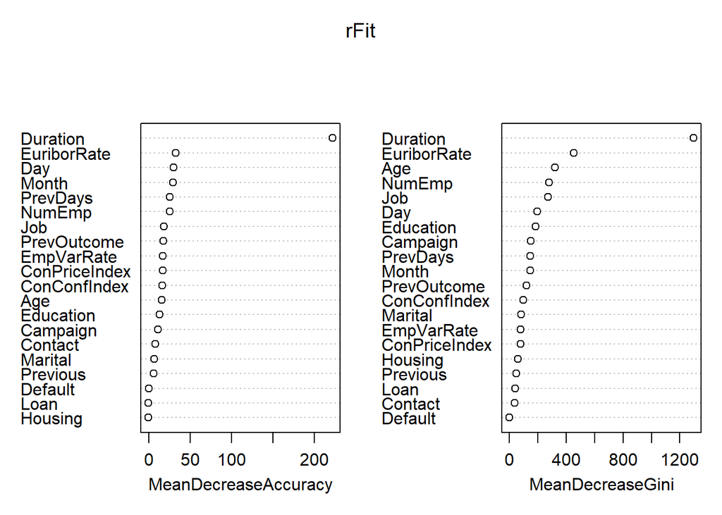

```r
varImpPlot(rFit)       #importance of the variables in the model (visual)
```

Step 10 : Use the model to predict `Subscribed` in the `assign2_MarketingPred.csv`.

```r
mktTest <- read.csv("assign2_MarketingPred.csv", header = TRUE)
levels(mktTest$Age) <- levels(mktTrain$Age)
levels(mktTest$Job) <- levels(mktTrain$Job)
levels(mktTest$Marital) <- levels(mktTrain$Marital)
levels(mktTest$Education) <- levels(mktTrain$Education)
levels(mktTest$Contact) <- levels(mktTrain$Contact)
levels(mktTest$Default) <- levels(mktTrain$Default)
levels(mktTest$Housing) <- levels(mktTrain$Housing)
levels(mktTest$Loan) <- levels(mktTrain$Loan)
levels(mktTest$Month) <- levels(mktTrain$Month)
levels(mktTest$Day) <- levels(mktTrain$Day)
levels(mktTest$Duration) <- levels(mktTrain$Duration)
levels(mktTest$Campaign) <- levels(mktTrain$Campaign)
levels(mktTest$PrevDays) <- levels(mktTrain$PrevDays)
levels(mktTest$Previous) <- levels(mktTrain$Previous)
levels(mktTest$PrevOutcome) <- levels(mktTrain$PrevOutcome)
levels(mktTest$EmpVarRate) <- levels(mktTrain$EmpVarRate)
levels(mktTest$ConPriceIndex) <- levels(mktTrain$ConPriceIndex)
levels(mktTest$ConConfIndex) <- levels(mktTrain$ConConfIndex)
levels(mktTest$EuriborRate) <- levels(mktTrain$EuriborRate)
levels(mktTest$NumEmp) <- levels(mktTrain$NumEmp)
```

Showing the result of the prediction on test set

```r
predTest <- predict(rFit, mktTest, type = "class")
summary(predTest)
```

```
##  no yes
## 906  94
```

```r
testdata_p3 <- mktTest
testdata_p3$Subscribed<-predTest
testdata_p3
```

```
##      Age           Job  Marital    Education Default Housing    Loan
## 1     29  entrepreneur  married      basic6y      no      no      no
## 2     25   blue-collar   single      basic9y      no      no      no
## 3     37   blue-collar  married   illiterate      no      no      no
## 4     31    technician  married professional      no      no      no
## 5     37         admin  married professional      no      no      no
## 6     49     housemaid  married   illiterate      no     yes      no
## 7     48   blue-collar  married      basic9y      no      no      no
## 8     52    technician  married   illiterate      no      no      no
## 9     35    management  married professional      no     yes      no
## 10    34    management  married professional      no      no      no
## 11    26         admin   single   highschool      no     yes      no
## 12    43         admin  married professional unknown      no      no
## 13    50         admin  married   highschool unknown      no      no
## 14    30    technician   single   illiterate      no     yes      no
```

[output cut: 2988 more lines]